# Thresholds and R₀: SIR versus SIS

NodeBasedModels.jl vignette N07: the epidemic thresholds of the pairwise SIR and SIS models, the generation-based R₀ and the growth-based threshold ratio

An SIR epidemic and an SIS epidemic on the same network have different thresholds. In SIR a recovered node is immune, so the partner that infected a node is no longer susceptible; in SIS it recovers to S and can be re-infected by the node it infected. The pairwise model sees this difference in its [II] → [SI] recovery term, and the two thresholds differ: on a k-regular network with the Bernoulli closure,

$$\tau_c^{\mathrm{SIR}} = \frac{\gamma}{k-2}, \qquad \tau_c^{\mathrm{SIS}} = \frac{\gamma}{k-1},$$

and on a configuration network with q = ⟨k(k − 1)⟩/⟨k⟩ they are γ/(q − 1) and γ/q (Keeling 1999; Kiss et al. 2017). This page derives both from the linearised pairwise equations, checks them against NodeBasedModels’ `epidemic_threshold` and against the ODEs, and separates two quantities that are both called “R₀”: the generation-based R₀ = T·κ_ex of NetworkEpiCore, defined only for models inside T_EB, and the growth-based threshold ratio of the pairwise model. There is no simulation on this page.

```julia
include(joinpath(@__DIR__, "..", "_shared", "setup.jl"))
using NetworkEpiCore, Catalyst, Plots
using LinearAlgebra
```

## The two models, twice

```julia
sir_rn = @reaction_network sir begin
    @parameters τ γ
    τ, S + I --> 2I
    γ, I --> R
end
sis_rn = @reaction_network sis begin
    @parameters τ γ
    τ, S + I --> 2I
    γ, I --> S
end
m_sir = contact_model(sir_rn)
m_sis = contact_model(sis_rn)
sc6 = scenario(:sir_reg6)          # SIR, 6-regular, τ = 1/6, γ = 1/4
sc3 = scenario(:sis_reg3)          # SIS, 3-regular, τ = 1/2, γ = 1/4
@assert isequivalent(m_sir, sc6.model) && isequivalent(m_sis, sc3.model)
net6, net3 = sc6.network, sc3.network
sys6  = node_based(m_sir, net6)
sys6F = generate_pairwise(sir_model(), net6, BernoulliClosure(); cumulative = true)
@assert vector_fields_equal(symbolic_ode(sys6), symbolic_ode(sys6F))
sys3  = node_based(m_sis, net3)
sys3F = generate_pairwise(sis_model(), net3, BernoulliClosure(); cumulative = true)
@assert vector_fields_equal(symbolic_ode(sys3), symbolic_ode(sys3F))
m_sis
```

```
ContactModel :sis  (source: Catalyst.ReactionSystem; method: stoichiometry; rates: PerContact)
  species       S (Sus)   I
  contacts      [1] S + I → I + I    τ    contact    infector I, entry I
  transitions   [2] I → S            γ    resus
  typing        T_net  ⇒  edge_based ✗  s_anchored ✗  pairwise ✓  individual ✓  pair ✓  stochastic ✓  mass_action ✓
  violations    `γ, I --> S` (type resus: node → sus) produces the susceptible species S.
  assumptions   Sus inferred as recipients \ contact products = {S}
```

SIS is outside the edge-based theory T_EB (the recovery produces the susceptible species), so NetworkEpiCore’s generation-based R₀ is not defined for it; the pairwise model is:

```julia
println(try basic_reproduction_number(m_sis, net3, sc3.params) catch e; join(first(split(sprint(showerror, e), '\n'), 2), '\n') end)
symbolic_ode(sys3)
```

```
AdmissibilityError: edge_based(:sis, ConfigurationNetwork(RegularDegree(3))):
  `γ, I --> S` (type resus: node → sus) produces the susceptible species S.
```

```
SymbolicODE :pairwise_sis (6 states)
  dS/dt = I(t)*γ - SI(t)*τ
  dI/dt = -I(t)*γ + SI(t)*τ
  dSS/dt = 2SI(t)*γ - 1.3333333333333333ifelse(S(t) == 0, 0, (SI(t)*SS(t)) / S(t))*τ
  dSI/dt = II(t)*γ - SI(t)*γ - SI(t)*τ + 0.6666666666666666ifelse(S(t) == 0, 0, (SI(t)*SS(t)) / S(t))*τ - 0.6666666666666666ifelse(S(t) == 0, 0, (SI(t)^2) / S(t))*τ
  dII/dt = -2II(t)*γ + 2SI(t)*τ + 1.3333333333333333ifelse(S(t) == 0, 0, (SI(t)^2) / S(t))*τ
  dcumulative/dt = SI(t)*τ
  parameters  γ, τ
```

## Linearising at the disease-free state

On a k-regular network with the Bernoulli closure [A S B] = ((k − 1)/k)[AS][SB]/[S], near the disease-free state ([S] ≈ 1, [SS] ≈ k) the triple [S S I] ≈ (k − 1)[SI] and [I S I] is quadratic. The infected pairs then follow a linear system. For SIS, recovery of either end of an [II] pair creates an [SI] pair:

$$\frac{d}{dt}\begin{pmatrix}[SI]\\ [II]\end{pmatrix} =
\begin{pmatrix}\tau(k-2)-\gamma & \gamma\\ 2\tau & -2\gamma\end{pmatrix}
\begin{pmatrix}[SI]\\ [II]\end{pmatrix},$$

while for SIR the recovered end of an [II] pair is an R, so the γ above the diagonal is absent and [SI] grows at rate τ(k − 2) − γ. The SIR threshold is τ(k − 2) = γ; the SIS threshold is where the determinant vanishes, 2γ(γ − τ(k − 2)) = 2γτ, i.e. τ(k − 1) = γ. Symbolically:

```julia
using Symbolics
@variables τ γ k
J_sis = [τ * (k - 2) - γ  γ; 2τ  -2γ]
J_sir = [τ * (k - 2) - γ  0; 2τ  -2γ]
det2(J) = J[1, 1] * J[2, 2] - J[1, 2] * J[2, 1]
println("SIS: det J = ", simplify(expand(det2(J_sis))), ";  det J + 2γ(τ(k − 1) − γ) = ",
        simplify(expand(det2(J_sis) + 2γ * (τ * (k - 1) - γ))))
println("SIR: J is triangular, eigenvalues ", J_sir[1, 1], " and ", J_sir[2, 2])
```

```
SIS: det J = 2(γ^2) + 2γ*τ - 2k*γ*τ;  det J + 2γ(τ(k − 1) − γ) = 0
SIR: J is triangular, eigenvalues -γ + (-2 + k)*τ and -2γ
```

## Against `epidemic_threshold`

NodeBasedModels reads the dynamics from the model (strictly SIR or strictly SIS) and returns τ_c for the given network and closure:

```julia
γ0 = 0.25
rows = map(3:8) do n
    net = ConfigurationNetwork(RegularDegree(n))
    p = Dict(:τ => 0.1, :γ => γ0)
    (n, epidemic_threshold(sir_model(), net, BernoulliClosure(); p), γ0 / (n - 2),
     epidemic_threshold(sis_model(), net, BernoulliClosure(); p), γ0 / (n - 1))
end
md_table(["k", "τ_c SIR", "γ/(k − 2)", "τ_c SIS", "γ/(k − 1)"], rows)
```

| k | τ_c SIR | γ/(k − 2) | τ_c SIS | γ/(k − 1) |
| --- | --- | --- | --- | --- |
| 3 | 0.25 | 0.25 | 0.125 | 0.125 |
| 4 | 0.125 | 0.125 | 0.08333 | 0.08333 |
| 5 | 0.08333 | 0.08333 | 0.0625 | 0.0625 |
| 6 | 0.0625 | 0.0625 | 0.05 | 0.05 |
| 7 | 0.05 | 0.05 | 0.04167 | 0.04167 |
| 8 | 0.04167 | 0.04167 | 0.03571 | 0.03571 |

On heterogeneous configuration networks the same holds with q = ⟨k(k − 1)⟩/⟨k⟩ (the excess degree) in place of k − 1:

```julia
hrows = map([("Poisson(5)", PoissonDegree(5)), ("negative binomial, mean 4, variance 8", NegBinDegree(mean = 4, var = 8)),
              ("bimodal {2: 5/6, 10: 1/6}", EmpiricalDegree(2 => 5 / 6, 10 => 1 / 6))]) do (name, d)
    net = ConfigurationNetwork(d); q = excess_degree(net); p = Dict(:τ => 0.1, :γ => γ0)
    (name, q, epidemic_threshold(sir_model(), net, BernoulliClosure(); p), γ0 / (q - 1),
     epidemic_threshold(sis_model(), net, BernoulliClosure(); p), γ0 / q)
end
md_table(["degrees", "q", "τ_c SIR", "γ/(q − 1)", "τ_c SIS", "γ/q"], hrows)
```

| degrees | q | τ_c SIR | γ/(q − 1) | τ_c SIS | γ/q |
| --- | --- | --- | --- | --- | --- |
| Poisson(5) | 5 | 0.0625 | 0.0625 | 0.05 | 0.05 |
| negative binomial, mean 4, variance 8 | 5 | 0.0625 | 0.0625 | 0.05 | 0.05 |
| bimodal {2: 5/6, 10: 1/6} | 5 | 0.0625 | 0.0625 | 0.05 | 0.05 |

## The scenario anchors

`anchors` prints each scenario’s parameters and thresholds. `:sir_reg6` sits at τ/τ_c = 8/3 with R₀ = 2; `:sis_reg3` has no edge-based R₀, and τ/τ_c = 4 is its threshold quantity:

```julia
a6 = anchors(sc6)
a3 = anchors(sc3)
@printf("SIR on 6-regular: τ_c = %.4f = γ/(k − 2) = %.4f;  SIS on 3-regular: τ_c = %.4f = γ/(k − 1) = %.4f\n",
        a6.τc, sc6.params[:γ] / 4, a3.τc, sc3.params[:γ] / 2)
@printf("on 3-regular, the SIR formula would give τ_c = %.4f, twice the SIS value\n",
        epidemic_threshold(sir_model(), net3, BernoulliClosure(); p = sc3.params))
```

```
:sir_reg6: γ = 0.25, τ = 0.166667; seeds I 0.01; t = 0:0.25:60; R₀ = 2; pairwise threshold τ_c = 0.0625, τ/τ_c = 2.66667 (canonical anchors)
:sis_reg3: γ = 0.25, τ = 0.5; seeds I 0.01; t = 0:0.25:80; edge-based R₀ not defined (model outside T_EB); pairwise threshold τ_c = 0.125, τ/τ_c = 4 (differs from the canonical anchors: no edge-based R₀, τ ≠ 1/6)
SIR on 6-regular: τ_c = 0.0625 = γ/(k − 2) = 0.0625;  SIS on 3-regular: τ_c = 0.1250 = γ/(k − 1) = 0.1250
on 3-regular, the SIR formula would give τ_c = 0.2500, twice the SIS value
```

## The thresholds in the ODEs

The early growth rate r of the pairwise model changes sign at τ_c. NodeBasedModels computes it from the linearised system; the log-slope of [I] in a solution from a small seed gives the same number, and the sign flips between 0.9τ_c and 1.1τ_c:

```julia
function logslope(sys, p, ρ, t1, t2)
    sol = solve_epidemic(sys; p, initial = SeedFraction(:I => ρ), tspan = (0.0, t2), saveat = [t1, t2],
                         reltol = 1e-10, abstol = 1e-14)
    I = compartment(sys, sol, :I)
    log(I[end] / I[1]) / (t2 - t1)
end
ns3 = network_structure(net3)
trows = []
for (name, m, net, sys) in (("SIR, 3-regular", m_sir, net3, node_based(m_sir, net3)),
                            ("SIS, 3-regular", m_sis, net3, sys3))
    dyn = name[1:3] == "SIR" ? :SIR : :SIS
    τc = epidemic_threshold(m, net, BernoulliClosure(); p = sc3.params)
    for f in (0.9, 1.1, 2.0)
        τv = f * τc
        r = early_growth_rate(ns3, BernoulliClosure(), τv, sc3.params[:γ]; dynamics = dyn)
        push!(trows, (name, f, τv, r, logslope(sys, Dict(:τ => τv, :γ => sc3.params[:γ]), 1e-8, 20.0, 40.0)))
    end
end
md_table(["model", "τ/τ_c", "τ", "early_growth_rate", "log-slope of [I] on t ∈ [20, 40]"], trows)
```

| model | τ/τ_c | τ | early_growth_rate | log-slope of [I] on t ∈ [20, 40] |
| --- | --- | --- | --- | --- |
| SIR, 3-regular | 0.9 | 0.225 | -0.025 | -0.02463 |
| SIR, 3-regular | 1.1 | 0.275 | 0.025 | 0.02514 |
| SIR, 3-regular | 2 | 0.5 | 0.25 | 0.2499 |
| SIS, 3-regular | 0.9 | 0.1125 | -0.02025 | -0.02025 |
| SIS, 3-regular | 1.1 | 0.1375 | 0.01977 | 0.01977 |
| SIS, 3-regular | 2 | 0.25 | 0.183 | 0.183 |

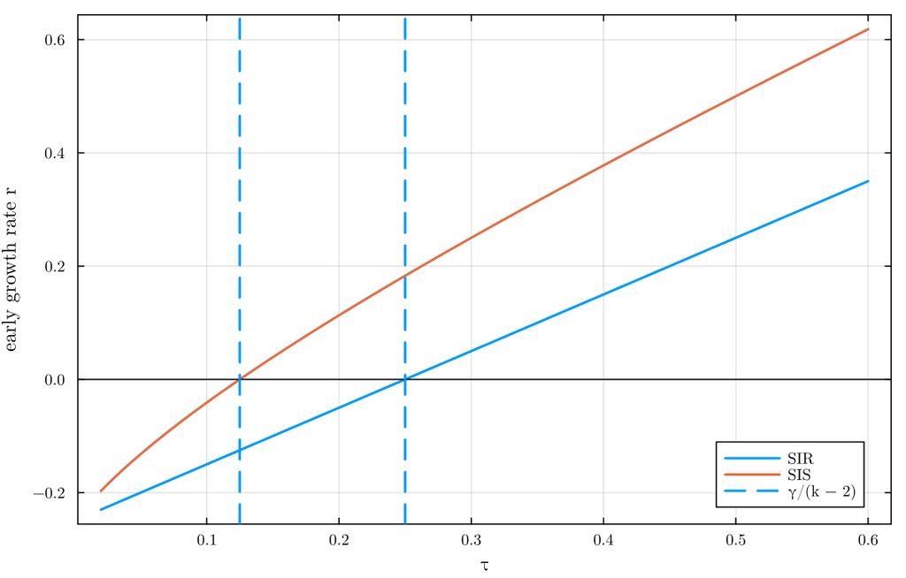

Figure 1: Early growth rate of the pairwise SIR and SIS models on the 3-regular network (γ = 1/4) against τ; the vertical lines are τ_c = γ/(k − 2) and γ/(k − 1).

```julia
τs = range(0.02, 0.6; length = 200)
plt = plot(τs, [early_growth_rate(ns3, BernoulliClosure(), t, 0.25; dynamics = :SIR) for t in τs]; label = "SIR",
           xlabel = "τ", ylabel = "early growth rate r")
plot!(plt, τs, [early_growth_rate(ns3, BernoulliClosure(), t, 0.25; dynamics = :SIS) for t in τs]; label = "SIS")
hline!(plt, [0.0]; color = :black, lw = 1, label = "")
vline!(plt, [0.25, 0.125]; ls = :dash, color = [1 2], label = ["γ/(k − 2)" "γ/(k − 1)"])
plt
```

## Two different “R₀”

For SIR the generation-based R₀ of NetworkEpiCore is R₀ = T·κ_ex with T = τ/(τ + γ): the mean number of neighbours an infected node infects, early in the epidemic. NodeBasedModels’ `basic_reproduction_number` of a pairwise model is a different quantity, the growth-based threshold ratio R = 1 + r/γ, which is τ(k − 2)/γ for SIR on a k-regular network. Both equal 1 at τ_c and both exceed 1 above it, but they are not equal elsewhere:

```julia
ns6 = network_structure(net6)
rrows = map((0.5, 1.0, 1.5, 8 / 3)) do f
    τv = f * sc6.params[:γ] / 4
    p = Dict(:τ => τv, :γ => sc6.params[:γ])
    (f, τv, basic_reproduction_number(m_sir, net6, p), basic_reproduction_number(ns6, BernoulliClosure(), τv, p[:γ]; dynamics = :SIR))
end
md_table(["τ/τ_c", "τ", "generation-based R₀ = T·κ_ex (NEC)", "growth-based R = 1 + r/γ (NBM)"], rrows)
```

| τ/τ_c | τ | generation-based R₀ = T·κ_ex (NEC) | growth-based R = 1 + r/γ (NBM) |
| --- | --- | --- | --- |
| 0.5 | 0.03125 | 0.5556 | 0.5 |
| 1 | 0.0625 | 1 | 1 |
| 1.5 | 0.09375 | 1.364 | 1.5 |
| 2.667 | 0.1667 | 2 | 2.667 |

At the anchors of `:sir_reg6` the generation-based R₀ is 2 while the growth-based ratio is 2.667. The two agree on the threshold, which is what either can be used for; only the generation-based R₀ is the number of secondary infections. The next-generation matrix of the SIR model (a single entry state, so it has rank one and R₀ is its only non-zero eigenvalue) gives the same R₀:

```julia
K = next_generation_matrix(m_sir, net6, sc6.params)
@printf("NGM = %s;  spectral radius %.6f;  T·κ_ex = %.6f\n", repr(round.(K; digits = 6)),
        maximum(abs.(eigvals(K))), transmissibility(m_sir, net6, sc6.params) * excess_degree(net6))
```

```
NGM = [2.0;;];  spectral radius 2.000000;  T·κ_ex = 2.000000
```

For SIS NodeBasedModels’ ratio has its own formula, R = (a + √((2γ − a)² + 8γ(a + τ)))/(2γ) with a = τ(k − 2) − γ, from the leading eigenvalue of the 2 × 2 system above:

```julia
R3 = basic_reproduction_number(ns3, BernoulliClosure(), sc3.params[:τ], sc3.params[:γ]; dynamics = :SIS)
r3 = early_growth_rate(ns3, BernoulliClosure(), sc3.params[:τ], sc3.params[:γ]; dynamics = :SIS)
τ3, γ3 = sc3.params[:τ], sc3.params[:γ]; a = τ3 * (3 - 2) - γ3
@printf(":sis_reg3: R = %.4f (formula %.4f), r = %.4f, R = 1 + r/γ = %.4f;  τ/τ_c = %.4f\n", R3,
        (a + sqrt((2γ3 - a)^2 + 8γ3 * (a + τ3))) / (2γ3), r3, 1 + r3 / γ3, τ3 / a3.τc)
```

```
:sis_reg3: R = 3.0000 (formula 3.0000), r = 0.5000, R = 1 + r/γ = 3.0000;  τ/τ_c = 4.0000
```

## References

Keeling, Matt J. 1999. “The Effects of Local Spatial Structure on Epidemiological Invasions.” *Proceedings of the Royal Society of London. Series B* 266 (1421): 859–67. https://doi.org/10.1098/rspb.1999.0716.

Kiss, István Z., Joel C. Miller, and Péter L. Simon. 2017. *Mathematics of Epidemics on Networks: From Exact to Approximate Models*. Vol. 46. Interdisciplinary Applied Mathematics. Springer. https://doi.org/10.1007/978-3-319-50806-1.